# Using Regression to Predict Global Video Game Sales

Honorio Vega, Andrew Sanchez, Bret Stine

May 3, 2018

### Goal/Hypothesis

Our team’s goal is to predict global video game sales based off of data collected in the past 15 years.

### Introduction

The data set is based off of video game sales as of January 2017. Origin of the data can be found using the link provided: https://www.kaggle.com/rush4ratio/video-game-sales-with-ratings. We decided to use this data set because of each member has an attachment to video games. Being able to predict future video game sales would be valuable to consumers and companies. The dataset comes with a structure of factors, ints, and numeric values. With Platform, year of release, and genre being of factors types. While variables that deal with sales and scores are broken up into numeric/ints.

### Read & Preprocessing

```r
> setwd('..')
> dat = read.csv(paste0(getwd(),"/data/Video_Game_Sales_as_of_Jan_2017.csv"))
> names(dat) = tolower(names(dat))
>
> # NAs
> sum(is.na(dat))
```

```
[1] 37396
```

```r
> # Before
> before = nrow(dat)
> before
```

```
[1] 17416
```

```r
> # Remove any rows with missing data
> dat = dat[complete.cases(dat),]
>
> # throw away rows with year less than 2000
> dat = dat[as.numeric(as.character(dat$year_of_release)) >= 2000,]
> # Scaling user score to 0-100
> dat$user_score = dat$user_score*10
```

The data set contains 17416 rows of data with a majority of games being released between 2000s and above.

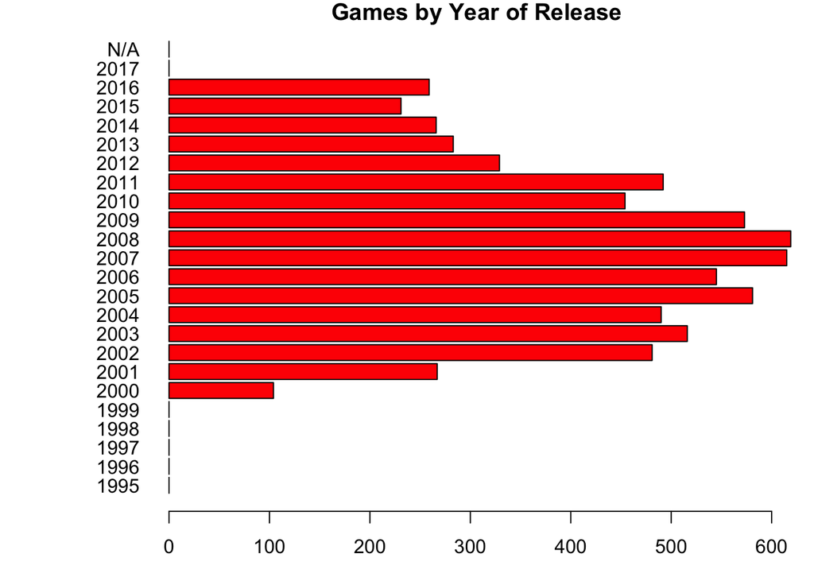

```r
> set.seed(123)
>
> par(mar=c(3,7,1,1))
> barplot(table(dat$year_of_release)[20:43], horiz=T, col="RED", las=1, main="Games by Year of Release")
```

After using complete cases we retain 40% of our data that is recent and relevant to our prediction of global sales.

```r
> dat = dat[complete.cases(dat),]
> after = nrow(dat)
> after/before
```

```
[1] 0.4079582
```

### Number of games in each Genre

Below is barplot this breaks down games by their genre. From face value we see that action genres is types of games that are being produced. It’s suprising to see that because as a group consensus, we typically played shooter genres.

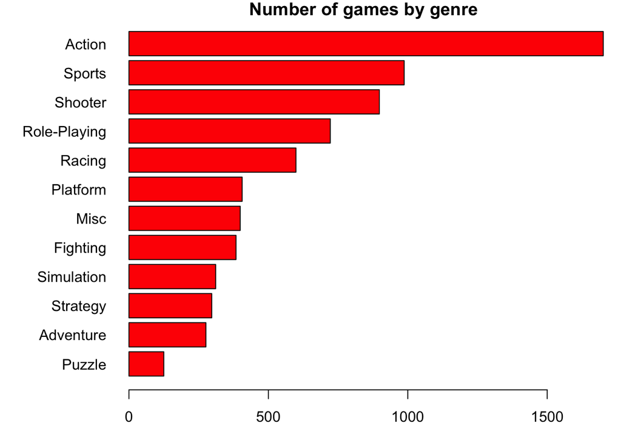

```r
> par(mar=c(3,7,1,1))
> barplot(sort(table(dat$genre)),horiz=TRUE,las=1,main="Number of games by genre",col="RED")
```

### Games by Platform

In this plot we see that PS2 has the highest amount of games per platform with over 1000 games. Its suprising to see that XOne and PS4 have relatively low amount of games than Wii and DS platforms, since they are the current generation of consoles.

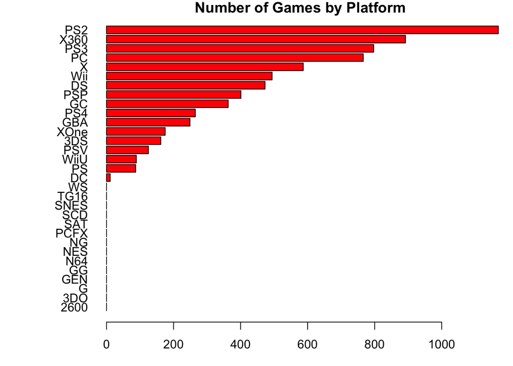

```r
> par(mar=c(3,7,1,1))
> barplot(sort(table(dat$platform)),horiz=TRUE,las=1,main="Number of Games by Platform",col="RED")
```

### Average Sales by Genres

We see that Misc is that top selling genre with mean sales of 1.06 globally. We notice that Misc Genre had the highest mean in sales compared to others. This was interesting because more Misc game small portion compared to other genres. Genres like shooters and platform come in second with a mean sales of 0.92 globally.

```r
> topGenres = aggregate(cbind(global_sales, na_sales, jp_sales, eu_sales) ~ genre, data=dat, function(x) mean(x))
> topGenres = topGenres[order(-topGenres$global_sales),]
> head(topGenres, 10)
```

```
          genre global_sales  na_sales   jp_sales  eu_sales
4          Misc    1.0661905 0.5727820 0.07927318 0.3090727
9       Shooter    0.9258352 0.5064922 0.02086860 0.2976503
5      Platform    0.9135468 0.4692118 0.10263547 0.2622906
11       Sports    0.8675583 0.4771023 0.03444782 0.2574367
7        Racing    0.7578297 0.3598998 0.03866444 0.2629716
1        Action    0.7076308 0.3482775 0.04312169 0.2282481
10   Simulation    0.6727653 0.3017685 0.08672026 0.2279100
8  Role-Playing    0.6602078 0.2934765 0.15461219 0.1575900
6        Puzzle    0.6368800 0.2716800 0.12120000 0.1924000
3      Fighting    0.6163021 0.3433594 0.06104167 0.1473698
```

### Highest Sales by Platform

We see in this data set that PS2 has highest sum of sales of all platforms. While X360 and PS3 come in second and third respectively. It is suprising to see PS2 have the highest sum of sales considering it was relased in March of 2000.

```r
> topPlatforms = aggregate(cbind(global_sales, na_sales, jp_sales, eu_sales) ~ platform, data=dat, function(x) sum(x))
> topPlatforms = topPlatforms[order(-topPlatforms$global_sales),]
> head(topPlatforms, 10)
```

```
   platform global_sales na_sales jp_sales eu_sales
8       PS2       965.91   483.06    76.49   261.19
16     X360       868.96   543.26    10.34   238.40
9       PS3       794.52   345.82    55.47   277.13
13      Wii       676.65   354.14    53.09   208.31
3        DS       385.88   175.41    84.04    96.18
10      PS4       266.30    92.85    10.96   121.16
15        X       217.40   157.15     1.20    51.42
6        PC       191.75    61.38     0.08   110.60
11      PSP       190.97    83.53    25.37    49.84
5        GC       161.73   109.71    16.12    31.38
```

### Critic Scores lead to Higher Global Sales?

From our plot we see that games that achieved a critic score greater than 50 tended to have higher global sales. While majority of games that didn’t achieve sales of 1 Million are distributed between 20-100 on critic score.

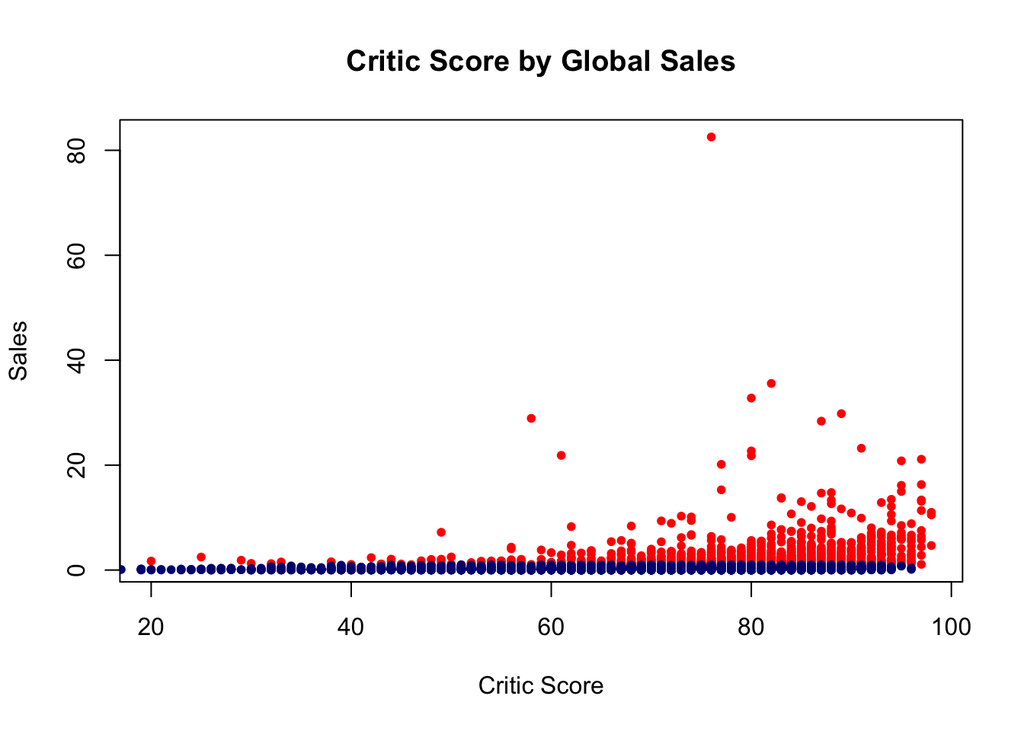

```r
> plot(global_sales[global_sales>1] ~ critic_score[global_sales>1], data=dat, col="RED", pch=20, xlab="Critic Score", ylab="Sales", main="Critic Score by Global Sales")
> points(global_sales[global_sales<1] ~ critic_score[global_sales<1], data=dat, col="NAVY", pch=20)
```

### Cumlative Distribution of Critic Score

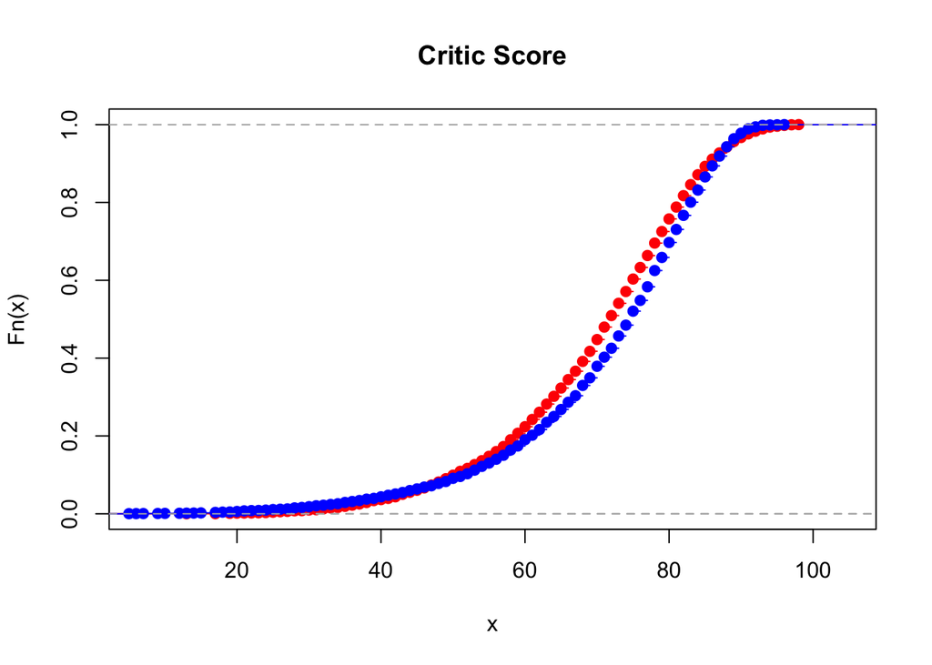

```r
> plot(ecdf(dat$critic_score), col="RED", main="Critic Score")
> lines(ecdf(dat$user_score), col="BLUE", main="User Score")
```

### Critic Scores vs User Scores by Genres

We see overall user scores are generally higher than critics scores. User scores are usually based off their experiences and impressions of a game, while critic scores are generally follow baselines of how to score a game.

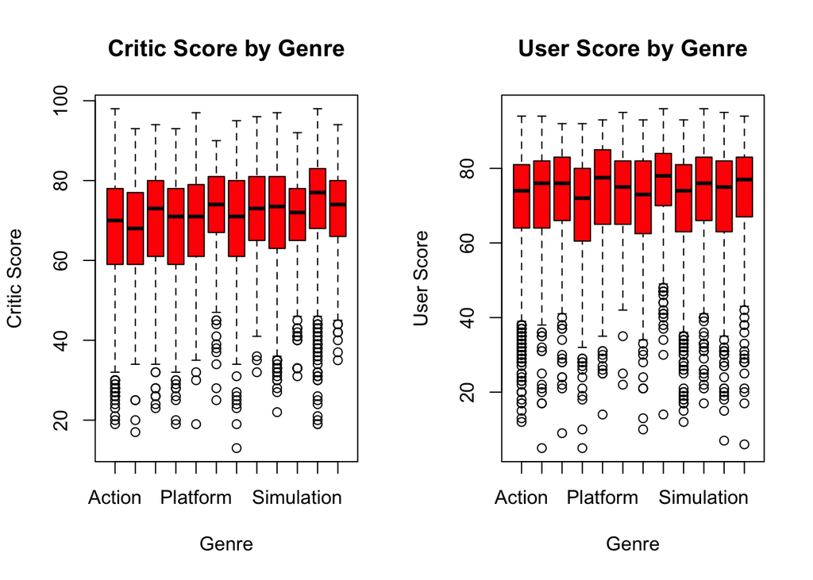

```r
> par(mfrow=c(1,2))
> # Critic Score
> plot(critic_score ~ genre, data=dat, main="Critic Score by Genre", xlab="Genre", ylab="Critic Score", col="RED")
> # User Score
> plot(user_score ~ genre, data=dat, main="User Score by Genre", xlab="Genre", ylab="User Score", col="RED")
```

### Differences Between Critics and Users

Here we get a closer view of critic and user scores and see for the most part there is small deviation. User scores tend to be higher per genre than their counter part critic scores.

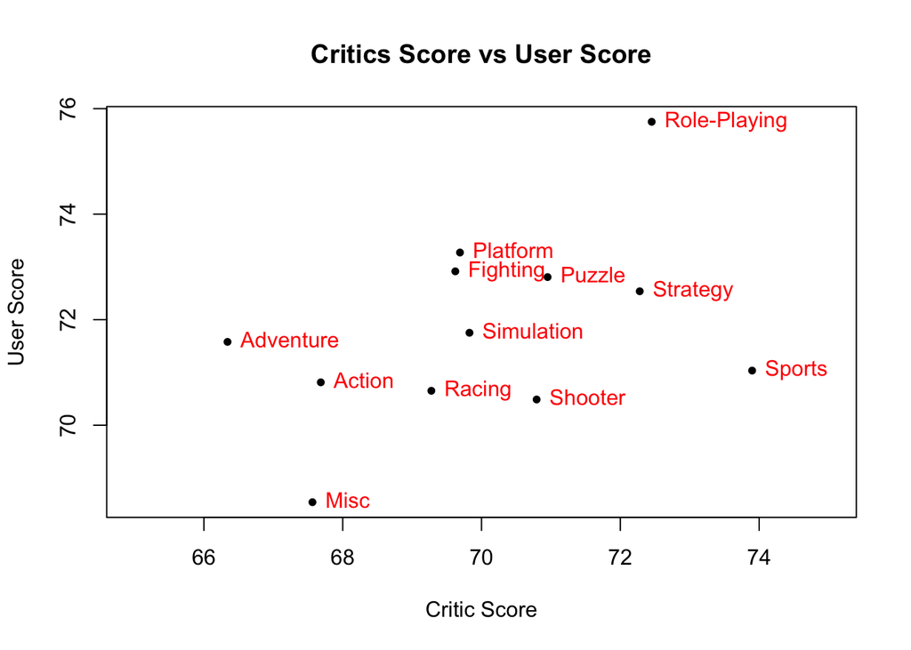

```r
> agg = aggregate(cbind(critic_score, user_score) ~ genre, data=dat, function(x) mean(x))
> plot(agg$critic_score, agg$user_score, xlim=c(65,75), ylab="User Score", xlab="Critic Score", pch=20, main="Critics Score vs User Score")
> text(agg$critic_score, agg$user_score, labels=agg$genre, pos=4, col="RED")
```

### Sampling & Splitting

We sample from the data and create training and test data sets with a 80/20 split respectively.

```r
> #
> set.seed(123)
>
> split = split_data(dat, c(4,1))
> tr_dat = split[[1]]
> te_dat = split[[2]]
```

### Cross Validation

```r
> rmse_cv = cross_validate_lm(dat, "global_sales", c("critic_score", "user_score", "genre"))
> rmse_cv
```

```
[1] 1.734377
```

### Linear Regression (Model 1)

For our first model we decided to keep it simple and use a Linear regression model. We built our model with features of critic score, user score, and genre. From our summary we see that critic score and user score of ***, this in turn means they have strong relationship to global sales.

```r
> fit = lm(global_sales ~ critic_score + user_score + genre, data=tr_dat)
> summary(fit)
```

```
Call:
lm(formula = global_sales ~ critic_score + user_score + genre,
    data = tr_dat)

Residuals:
   Min     1Q Median     3Q    Max
-1.705 -0.624 -0.279  0.171 81.692

Coefficients:
                   Estimate Std. Error t value Pr(>|t|)
(Intercept)       -1.147195   0.146718  -7.819 6.30e-15 ***
critic_score       0.036502   0.002235  16.334  < 2e-16 ***
user_score        -0.009133   0.002114  -4.321 1.58e-05 ***
genreAdventure    -0.344649   0.137600  -2.505 0.012283 *
genreFighting     -0.121446   0.115840  -1.048 0.294500
genreMisc          0.448489   0.115835   3.872 0.000109 ***
genrePlatform      0.159832   0.114401   1.397 0.162431
genrePuzzle       -0.109746   0.190244  -0.577 0.564051
genreRacing       -0.020189   0.098204  -0.206 0.837124
genreRole-Playing -0.169904   0.093673  -1.814 0.069763 .
genreShooter       0.148684   0.087273   1.704 0.088499 .
genreSimulation   -0.041180   0.134163  -0.307 0.758901
genreSports       -0.048098   0.084537  -0.569 0.569406
genreStrategy     -0.588129   0.131703  -4.466 8.14e-06 ***
---
Signif. codes:  0 '***' 0.001 '**' 0.01 '*' 0.05 '.' 0.1 ' ' 1

Residual standard error: 1.869 on 5669 degrees of freedom
Multiple R-squared:  0.06132,   Adjusted R-squared:  0.05917
F-statistic: 28.49 on 13 and 5669 DF,  p-value: < 2.2e-16
```

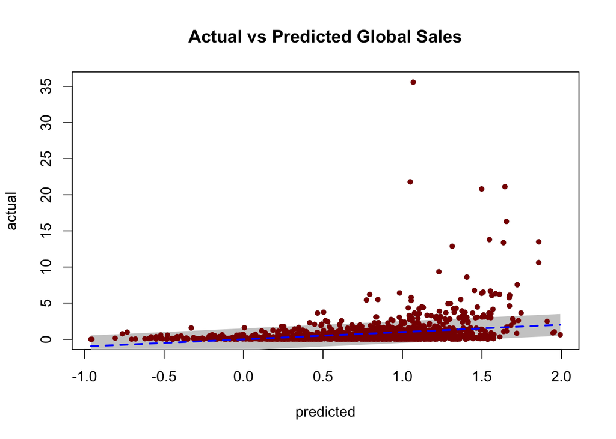

```r
> # Plot
> predicted = predict(fit, newdata=te_dat)
> actual = te_dat$global_sales
> plot_predict_actual(predicted, actual, 1.5, "Actual vs Predicted Global Sales")
```

We then test our linear regression model by computing the root mean squared error(RMSE). With RMSE the lower the value the better, with our model we achieved a RMSE value of 1.79.

```r
> lmErrs1 = actual-predicted
> rmse = sqrt(mean((actual-predicted)^2))
> rmse
```

```
[1] 1.790033
```

After we get our see our rmse, we plot the fit to get a better understanding of our model. In our first plot Residuals vs Fitted what we’re trying to achieve is level red line. Residuals is the difference between the data and our predicted line created in the linear regression model. As you can see we achieved a near flat line which in turn shows that our model assumptions hold true. The second plot we’re trying achieve plotted points along the dotted red-line, this in turn is testing gaussian.

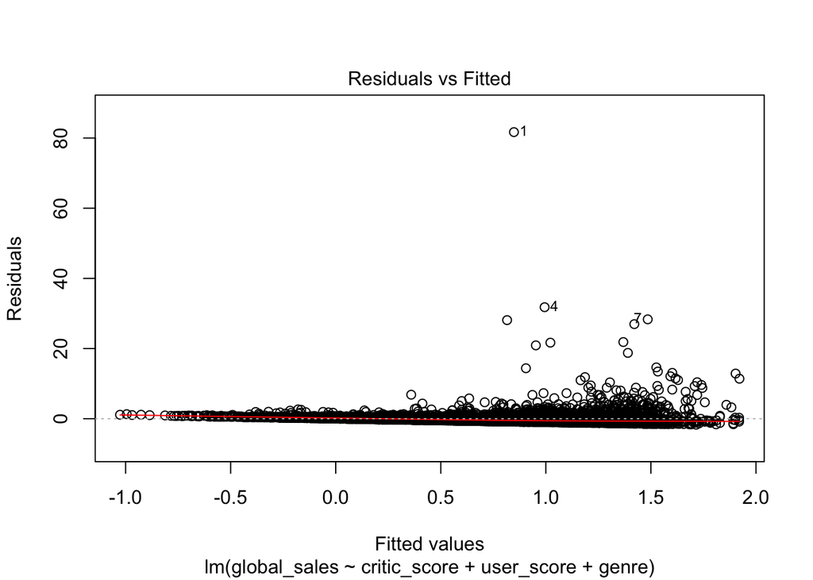

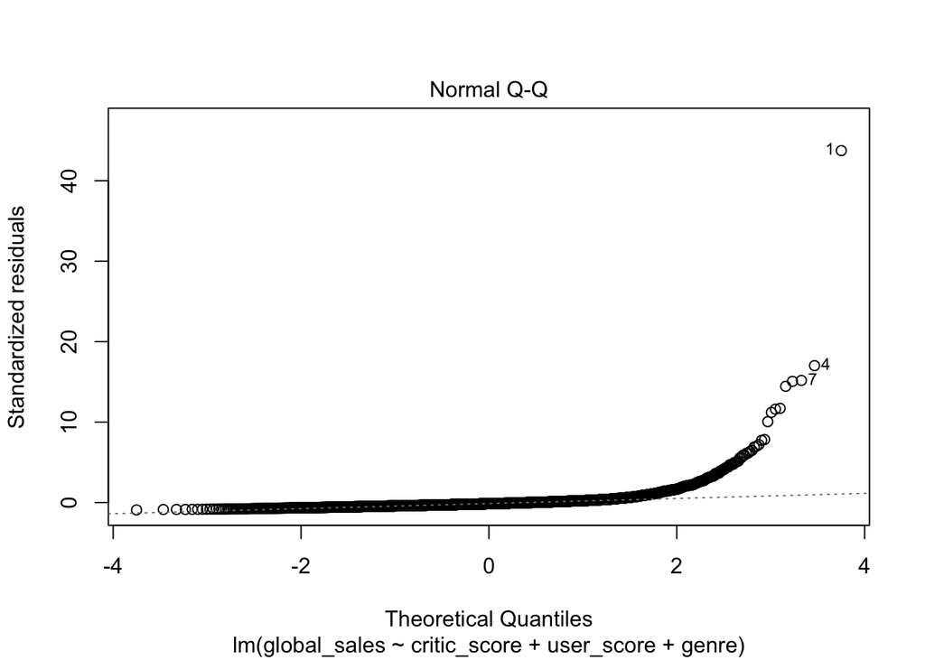

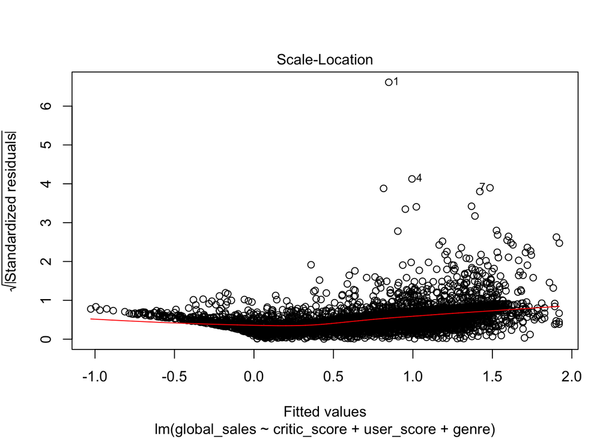

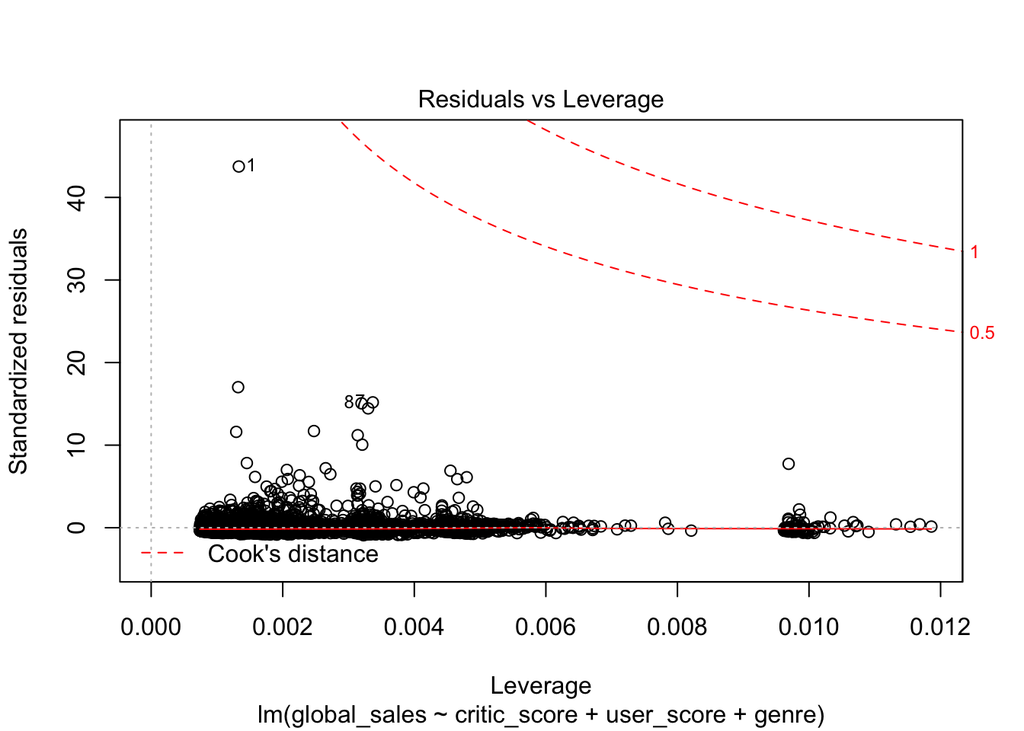

```r
> plot(fit)
```

### Cross Validation

```r
> rmse_cv = cross_validate_lm(dat, "global_sales", c("platform", "genre", "user_count"))
> rmse_cv
```

```
[1] 1.689961
```

### Linear Regression (Model 2)

With our second model we decided to try and improve the our model by choosing different features. This time the features we choose are genre, platform, and user count.

```r
> fit = lm(global_sales ~ genre + platform + user_count, data=tr_dat)
> summary(fit)
```

```
Call:
lm(formula = global_sales ~ genre + platform + user_count, data = tr_dat)

Residuals:
   Min     1Q Median     3Q    Max
-8.853 -0.556 -0.272  0.128 80.817

Coefficients:
                    Estimate Std. Error t value Pr(>|t|)
(Intercept)        6.643e-01  1.645e-01   4.038 5.47e-05 ***
genreAdventure    -2.329e-01  1.354e-01  -1.720 0.085460 .
genreFighting      6.341e-03  1.138e-01   0.056 0.955581
genreMisc          4.824e-01  1.140e-01   4.230 2.37e-05 ***
genrePlatform      2.707e-01  1.136e-01   2.382 0.017234 *
genrePuzzle       -5.380e-02  1.913e-01  -0.281 0.778594
genreRacing        1.901e-01  9.684e-02   1.963 0.049683 *
genreRole-Playing -9.489e-02  9.268e-02  -1.024 0.305935
genreShooter       1.954e-01  8.635e-02   2.263 0.023702 *
genreSimulation    3.042e-01  1.331e-01   2.286 0.022317 *
genreSports        3.077e-01  8.260e-02   3.725 0.000197 ***
genreStrategy     -6.706e-02  1.333e-01  -0.503 0.614962
platformDC        -4.673e-01  7.107e-01  -0.657 0.510910
platformDS         1.066e-01  1.861e-01   0.573 0.566956
platformGBA       -2.749e-01  2.034e-01  -1.351 0.176623
platformGC        -4.227e-01  1.927e-01  -2.194 0.028275 *
platformPC        -1.081e+00  1.803e-01  -5.998 2.12e-09 ***
platformPS        -8.275e-02  2.726e-01  -0.304 0.761496
platformPS2       -2.866e-02  1.711e-01  -0.167 0.867030
platformPS3       -2.985e-02  1.762e-01  -0.169 0.865499
platformPS4       -3.088e-01  2.017e-01  -1.531 0.125742
platformPSP       -3.065e-01  1.906e-01  -1.608 0.107839
platformPSV       -5.383e-01  2.430e-01  -2.215 0.026783 *
platformWii        4.506e-01  1.847e-01   2.439 0.014756 *
platformWiiU      -2.200e-01  2.711e-01  -0.812 0.417091
platformX         -4.721e-01  1.824e-01  -2.588 0.009679 **
platformX360      -1.434e-03  1.751e-01  -0.008 0.993467
platformXOne      -2.940e-01  2.241e-01  -1.312 0.189694
user_count         9.287e-04  4.397e-05  21.123  < 2e-16 ***
---
Signif. codes:  0 '***' 0.001 '**' 0.01 '*' 0.05 '.' 0.1 ' ' 1

Residual standard error: 1.829 on 5654 degrees of freedom
Multiple R-squared:  0.1034,    Adjusted R-squared:  0.09894
F-statistic: 23.28 on 28 and 5654 DF,  p-value: < 2.2e-16
```

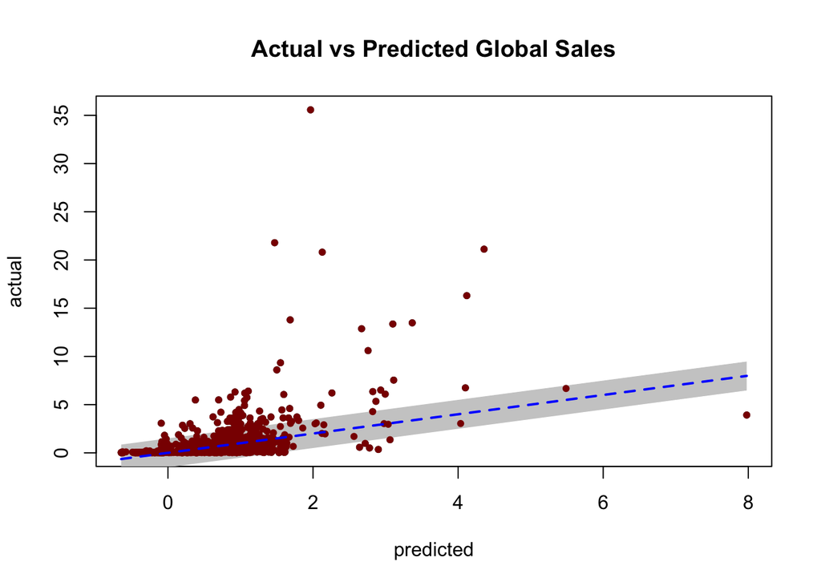

```r
> # Plot
> predicted = predict(fit, newdata=te_dat)
> actual = te_dat$global_sales
> plot_predict_actual(predicted, actual, 1.5, "Actual vs Predicted Global Sales")
```

This time with our second model we achieved lower RMSE score of 1.68, which is an improvement from the previous linear model.

```r
> lmErrs2 = actual-predicted
> rmse = sqrt(mean((actual-predicted)^2))
> rmse
```

```
[1] 1.682044
```

After the RMSE plot, we run our diagnostic plots to better interpret out model. We see in the first plot the our red line nearly resembles a straight line, which in turn means our models assumptions hold true. As for the second plot, it didn’t do as well as the first linear regression model as what we’re looking for is points plotted along the dotted line. In the beginning and end the points tend to fall stray off.

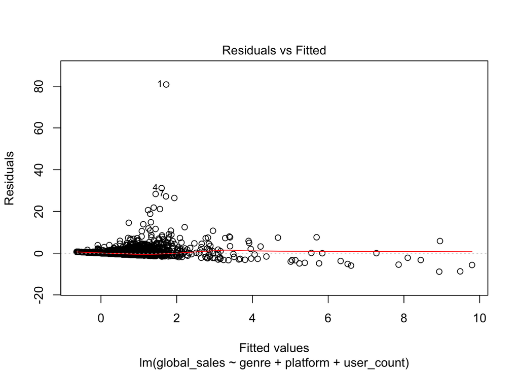

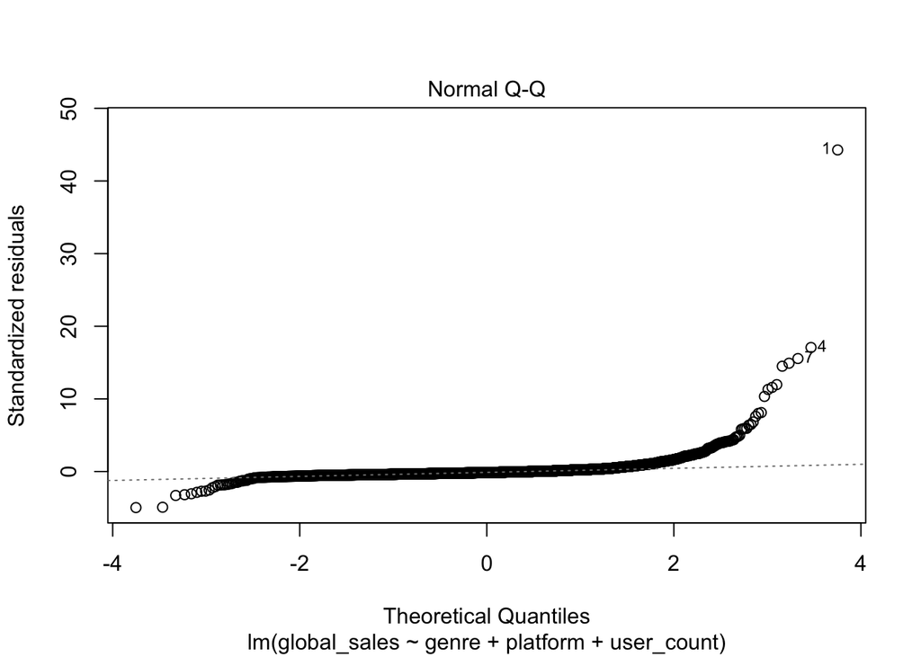

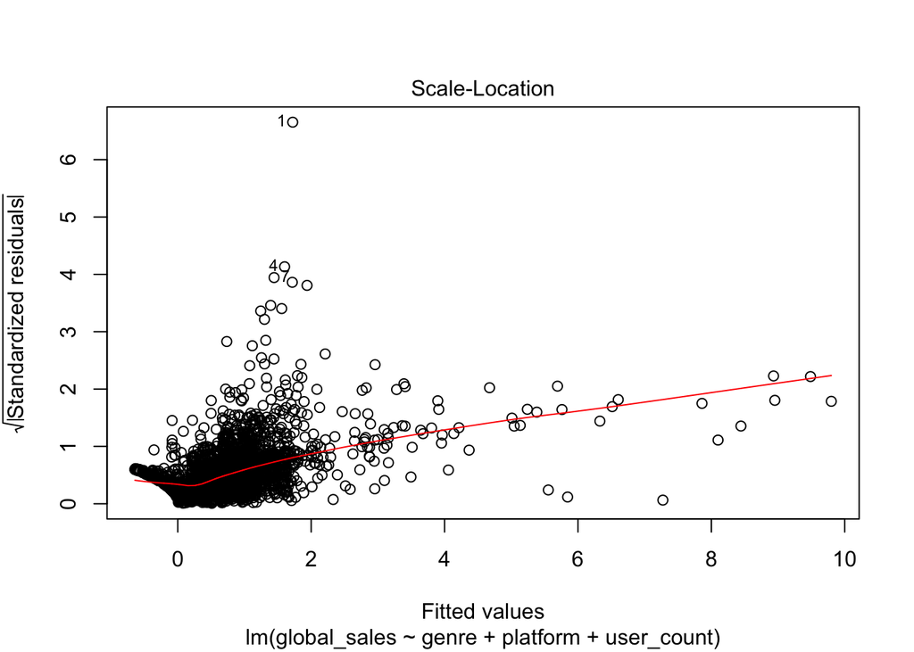

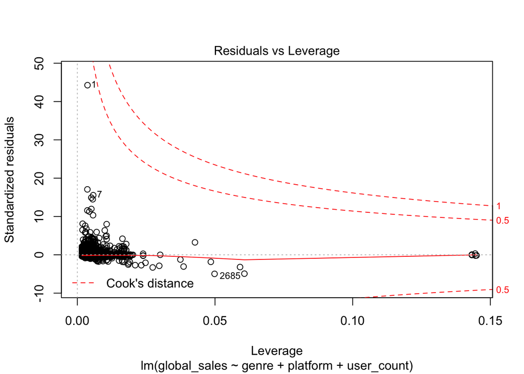

```r
> plot(fit)
```

### Regression Tree (Model 3)

```r
> fit = rpart(global_sales ~ genre + platform + user_count, data=tr_dat)
```

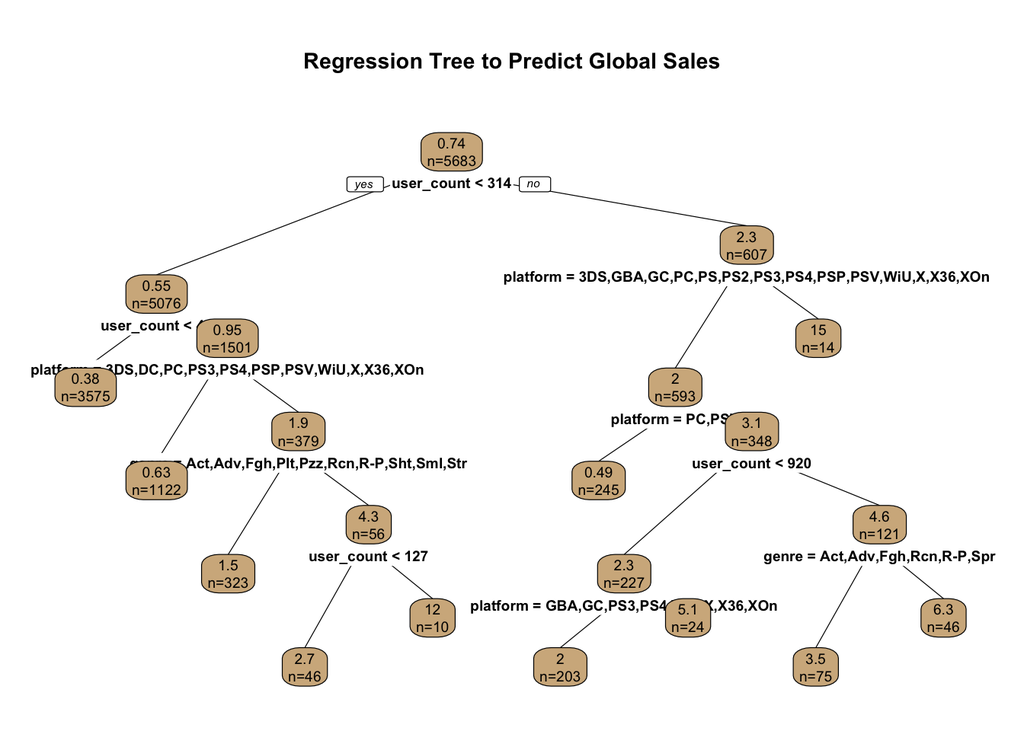

```r
> prp(fit, extra=1, varlen=-10,main="Regression Tree to Predict Global Sales", type = 2, tweak = 1.5, box.col="tan")
```

```r
> predicted = predict(fit, te_dat)
> regErrs = te_dat$global_sales - predicted
> rmse = sqrt(mean(regErrs^2))
> rmse
```

```
[1] 1.495122
```

Looking at the predicted line versus the actual points, the predicted line follows the points to a certain extent. However, the plot_predict_actual is designed to work with linear regression. Here, we are using it for Regression Trees, but the point of the plot is to show if the predicted line at all matches the points. From the plotted points, the predicted line follows the points and implies that the model works with the data.

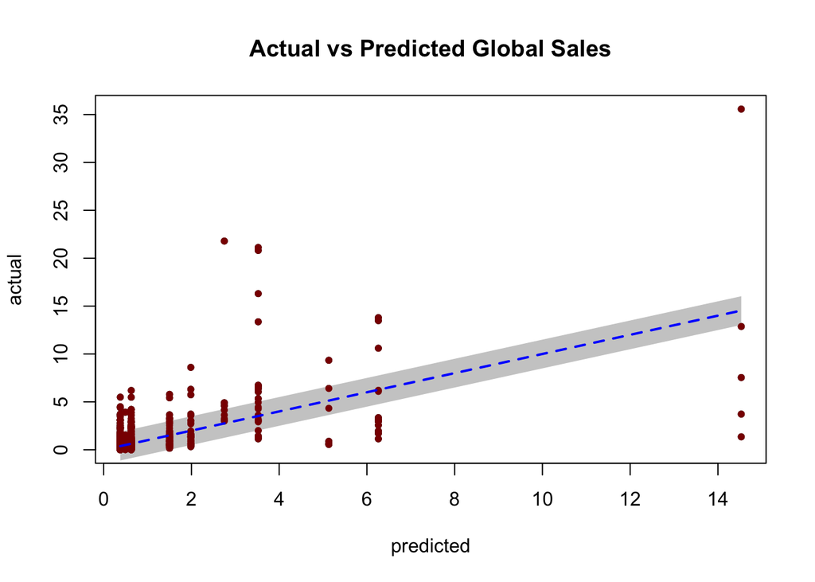

```r
> plot_predict_actual(predicted, te_dat$global_sales, 1.5, "Actual vs Predicted Global Sales")
```

### Comparison of Models

For each model we plot a histogram of its errors. This will allow us to get a visualization of the errors and compare our models to one another. We see with all 3 models the errors do not stray far from our predictions and that closely resemble one another. Regression trees are more prone to overfitting due it being a non-parametric model, but in this case our regression tree holds true since it similiar to our linear models.

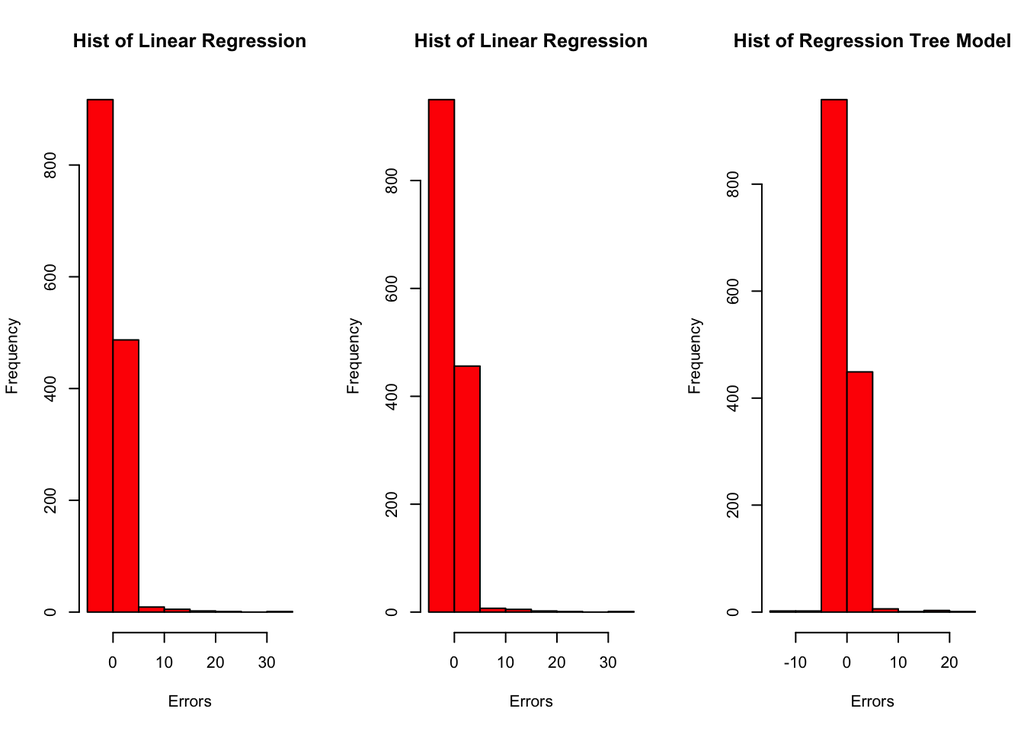

```r
> par(mfrow=c(1,3))
> hist(lmErrs1, col="RED", main="Hist of Linear Regression", xlab="Errors")
> hist(lmErrs2, col="RED", main="Hist of Linear Regression", xlab="Errors")
> hist(regErrs, col="RED", main="Hist of Regression Tree Model", xlab="Errors")
```

### Our Conclusion

Based on our initial goal/hypothesis, we were able to predict global video game sales. Our Regression Tree model achieved the lowest RMSE out of the three models. Because of this, using Regression Tree to predict global video game sales was the best machine learning algorithm, based on the two algorithms we used. There was also some interesting things in the data, one such misc had the highest mean of sales compared to other genres; Misc is a much smaller percentage of games compared to other genres such as actions and sports games. Games that achieved high critic score tended to have higher global sales compared to games that did not achieve a good critic score.

### Libraries and Functions used in the project

```r
> library(rpart)
> library(rpart.plot)
> library(maptree)
> source("https://raw.githubusercontent.com/grbruns/cst383/master/lin-regr-util.R")
> # perform n-fold cross-validation on the given data set; return mean rmse
> # dat - a data frame
> # y - response variable, as a string
> # xs - predictor variables, as a vector of strings
> # n   - the 'n' in n-fold cross-validation
> cross_validate_lm = function(dat, y, xs, n=10) {
+   # create the formula to be used with lm
+   ff = reformulate(xs, y)
+
+   # compute indexes of the groups
+   k = nrow(dat)
+   dat1 = dat[sample(1:k),]     # shuffle the data
+   starts = seq(1, k, by=floor(k/n))[1:n]
+   ends = c(starts[2:n]-1, k)
+
+   sum_rmse = 0
+   for (i in 1:n) {
+     tests = starts[i]:ends[i]
+     fit = lm(ff, data=dat1[-tests,])
+     if (length(fit$coefficients) > fit$rank) {
+       print(paste0("rank-deficit problem with ", ff))
+     }
+     predicted = predict(fit, newdata=dat1[tests,])
+     actual = dat1[tests,y]
+     rmse = sqrt(mean((actual-predicted)^2))
+     sum_rmse = sum_rmse + rmse
+     # print(paste0(i,": RMSE = ",rmse))
+   }
+   return(sum_rmse/n)
+ }
```